# Homework 5

```r
library(ggplot2)
load("../data/RainData.RData")      # gives `dati` (stations, all years) and `grid` (prediction points)

# Coordinates in km, centred on the stations (better numerical behaviour); altitude in km.
# The same centring is used for the stations and for the grid.
x0 <- mean(dati$XUTM); y0 <- mean(dati$YUTM)
prep <- function(d) transform(d, x = (XUTM - x0) / 1000, y = (YUTM - y0) / 1000, alt = Quota / 1000)
dati <- prep(dati[!is.na(dati$totanno), ])
grid <- prep(grid)
stopifnot(!anyNA(dati[, c("x", "y", "alt")]), !anyNA(grid[, c("x", "y", "alt")]))

# One list per year: data, response, coordinates and matrix of distances between stations
yrs <- lapply(split(dati, dati$anno), function(d)
  list(data = d, z = d$totanno, co = as.matrix(d[, c("x", "y")]),
       D = as.matrix(dist(d[, c("x", "y")]))))
years <- names(yrs)
years <- c("1973", "1974", "1980")
yrs <- yrs[years]
```

## Homework 5

$$Z_t(s) = X(s)\beta_t + W_t(s) + \varepsilon_t(s)$$

where $X(s)\beta_t$ is a spatial trend (including coordinates and/or altitude), $W_t(s)$ is a Gaussian spatial process with a partial sill $\sigma^2_t$ and range $\phi_t$, and $\varepsilon_t(s)$ is the nugget effect with variance $\tau^2_t$.

Unlike in Homework 4 where these parameters were assumed fixed and estimated by maximum likelihood (ML), here we adopt a **Bayesian framework**. The spatial parameters ($\beta_t, \sigma^2_t, \phi_t, \tau^2_t$) are treated as random variables with assigned prior distributions. This allows us to integrate the uncertainty of the parameter estimation directly into our spatial predictions.

Following the homework instructions, the steps are:

1. implement Bayesian kriging (`krige.bayes`) on the estimation grid for each year, dynamically utilizing the best trend and covariance structures identified in Homework 4;
2. evaluate the precision of the spatial estimates by extracting the 95% pointwise credibility intervals from the posterior predictive distributions;
3. discuss and compare the performance of these Bayesian models to the ML models from Homework 4, using Proper scores (CRPS and LogS) evaluated on the observation points.

## AI Prompt

As in the previous homeworks, we gave the AI the data, the method we wanted and the checks to do.

> I’m a student in spatial statistics. I have a dataset in R from RainData.RData which contains yearly total rainfall (totanno) at various weather stations, along with their UTM coordinates and altitude. I am working on Homework 5, which builds directly upon my Homework 4 results for the years 1973, 1974, and 1980. For this new assignment, I need to transition from a maximum likelihood framework to a Bayesian approach. For each of the three years independently, please help me write R code in chunks for an RMarkdown document to accomplish the following: 1) Implement Bayesian kriging on the estimation grid using krige.bayes from the geoR package. Configure the models dynamically based on the best trend and covariance structures found in Homework 4 (1973: Spherical covariance with linear coordinates and altitude trend; 1974: Spherical covariance with altitude trend; 1980: Exponential covariance with altitude trend). Define reasonable discrete priors for the spatial parameters to keep computation time manageable.2) Evaluate precision by extracting the posterior median predictions and computing the 95% credibility intervals (2.5% and 97.5% quantiles) for each point on the grid. 3) Compute Proper scores (CRPS and LogS) for these Bayesian models using the scoringRules package, so I can formally compare their performance with the frequentist models from Homework 4.

**Answer.** Here is the analysis asked for by these prompt.

## Part I : Implementing of the Bayesian Kriging

To implement the Bayesian kriging, we use the `krige.bayes` function from the `geoR` package. The provided R code automates this process across the three years of interest (1973, 1974, and 1980) using a `for` loop.

```r
# Load required package
library(geoR)

# Create a list to store the results for each year
bayes_results <- list()

# Prepare grid points and altitude covariate for prediction
pred_grid <- grid[, c("x", "y")]
pred_covar <- data.frame(alt = grid$alt)

# Define discrete grids for the priors of spatial parameters (reduced for faster computation)
prior_settings <- prior.control(
  phi.discrete = seq(5, 100, length.out = 10),
  phi.prior = "uniform",
  tausq.rel.discrete = seq(0, 1, length.out = 5),
  tausq.rel.prior = "uniform",
  sigmasq.prior = "reciprocal"
)


# Loop over each year to fit the model and predict
for (yr in years) {

  # 1. Extract data and convert to a geodata object
  current_data <- yrs[[yr]]$data
  geo_obj <- as.geodata(current_data,
                        coords.col = which(names(current_data) %in% c("x", "y")),
                        data.col = which(names(current_data) == "totanno"),
                        covar.col = which(names(current_data) == "alt"))

  # 2. Dynamic model and trend selection based on HW4 results[cite: 3]
  if (yr == "1973") {
    # 1973: Spherical covariance and linear + altitude trend[cite: 3]
    cov_mod <- "spherical"
    trend_d <- ~ geo_obj$coords[, 1] + geo_obj$coords[, 2] + geo_obj$covar$alt
    trend_l <- ~ pred_grid[, 1] + pred_grid[, 2] + pred_covar$alt
  } else if (yr == "1974") {
    # 1974: Spherical covariance and altitude trend[cite: 3]
    cov_mod <- "spherical"
    trend_d <- ~ alt
    trend_l <- ~ pred_covar$alt
  } else {
    # 1980: Exponential covariance and altitude trend[cite: 3]
    cov_mod <- "exponential"
    trend_d <- ~ alt
    trend_l <- ~ pred_covar$alt
  }

  # Perform Bayesian kriging with dynamic parameters
  kb_model <- krige.bayes(geo_obj,
                          locations = pred_grid,
                          model = model.control(trend.d = trend_d,
                                                trend.l = trend_l,
                                                cov.model = cov_mod),
                          prior = prior_settings,
                          output = output.control(n.predictive = 1000,
                                                  quantile = c(0.025, 0.5, 0.975)))

  # 3. Store the results
  bayes_results[[yr]] <- kb_model
}
```

[output not shown]

[output cut: 41 more lines]

[output not shown]

## Part II : Evaluating the estimates’ precision

Following the model fitting, we extract the predictions to evaluate the precision of our estimates across the spatial grid. For each year, we use the posterior median (the 50% quantile) as our robust point estimate for the annual rainfall.

```r
# --- Year 1973 ---
# Extracting results to evaluate uncertainty for the year 1973[cite: 1]
krige_1973 <- bayes_results[["1973"]]$predictive

# Predictions (posterior mean or median)
pred_mean_73 <- krige_1973$mean
pred_median_73 <- krige_1973$quantiles[, 2] # 2nd column is 0.5 (median)

# 95% Credible Intervals[cite: 1]
ci_lower_73 <- krige_1973$quantiles[, 1] # 1st column is 0.025
ci_upper_73 <- krige_1973$quantiles[, 3] # 3rd column is 0.975

# Uncertainty magnitude (width of the interval)
incertitude_73 <- ci_upper_73 - ci_lower_73


# --- Year 1974 ---
# Extracting results to evaluate uncertainty for the year 1974[cite: 1]
krige_1974 <- bayes_results[["1974"]]$predictive

# Predictions (posterior mean or median)
pred_mean_74 <- krige_1974$mean
pred_median_74 <- krige_1974$quantiles[, 2]

# 95% Credible Intervals[cite: 1]
ci_lower_74 <- krige_1974$quantiles[, 1]
ci_upper_74 <- krige_1974$quantiles[, 3]

# Uncertainty magnitude (width of the interval)
incertitude_74 <- ci_upper_74 - ci_lower_74


# --- Year 1980 ---
# Extracting results to evaluate uncertainty for the year 1980[cite: 1]
krige_1980 <- bayes_results[["1980"]]$predictive

# Predictions (posterior mean or median)
pred_mean_80 <- krige_1980$mean
pred_median_80 <- krige_1980$quantiles[, 2]

# 95% Credible Intervals[cite: 1]
ci_lower_80 <- krige_1980$quantiles[, 1]
ci_upper_80 <- krige_1980$quantiles[, 3]

# Uncertainty magnitude (width of the interval)
incertitude_80 <- ci_upper_80 - ci_lower_80
```

To quantify the estimation uncertainty, we compute the 95% pointwise credibility intervals by extracting the 2.5% and 97.5% quantiles from the posterior predictive distribution. The width of this interval (upper bound minus lower bound) represents the magnitude of the uncertainty at each specific grid location. Unlike the maximum likelihood approach, these credibility intervals directly incorporate the uncertainty regarding the true values of the spatial covariance parameters.

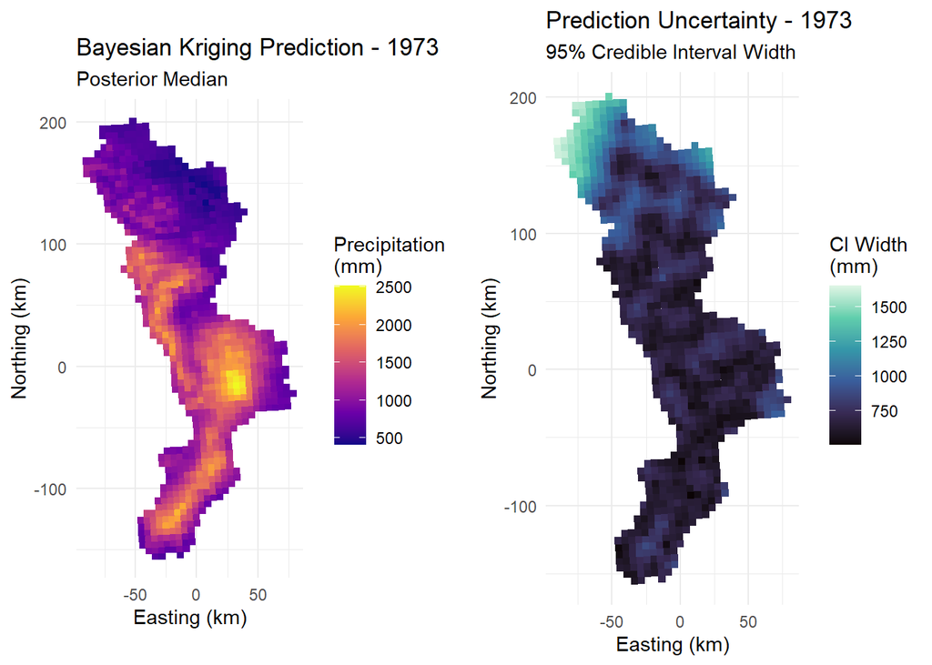

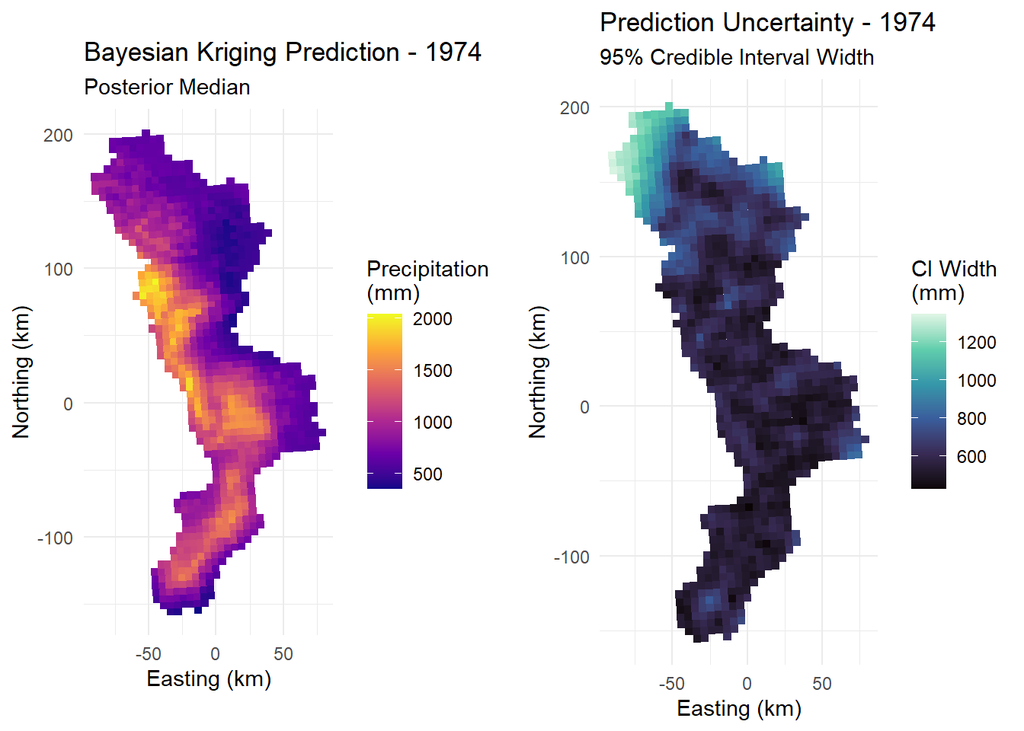

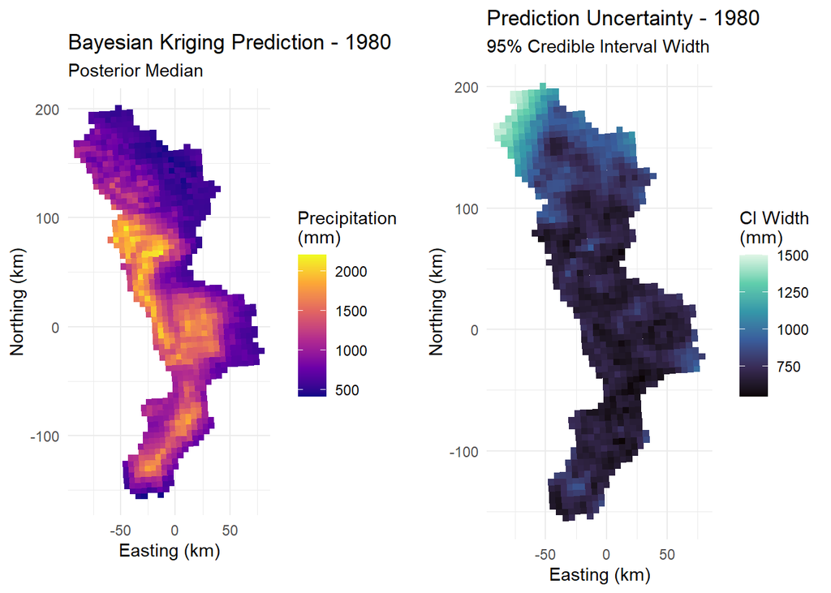

```r
# Load required packages for plotting
library(ggplot2)
library(gridExtra)

# Loop over the three years
for (yr in years) {

  # 1. Extract results for the current year
  krige_res <- bayes_results[[yr]]$predictive

  # Calculate median and uncertainty directly
  pred_median <- krige_res$quantiles[, 2] # Median (50%)
  ci_lower <- krige_res$quantiles[, 1]    # 2.5%
  ci_upper <- krige_res$quantiles[, 3]    # 97.5%
  incertitude <- ci_upper - ci_lower

  # 2. Create the data frame for the current year
  plot_data <- data.frame(
    x = pred_grid[, 1],
    y = pred_grid[, 2],
    Prediction = pred_median,
    Uncertainty = incertitude
  )

  # 3. Map of the predictions
  map_pred <- ggplot(plot_data, aes(x = x, y = y, color = Prediction)) +
    geom_point(shape = 15, size = 1.5) +
    scale_color_viridis_c(option = "plasma", name = "Precipitation\n(mm)") +
    coord_fixed() +
    theme_minimal() +
    labs(title = paste("Bayesian Kriging Prediction -", yr),
         subtitle = "Posterior Median",
         x = "Easting (km)", y = "Northing (km)")

  # 4. Map of the uncertainty
  map_uncert <- ggplot(plot_data, aes(x = x, y = y, color = Uncertainty)) +
    geom_point(shape = 15, size = 1.5) +
    scale_color_viridis_c(option = "mako", name = "CI Width\n(mm)") +
    coord_fixed() +
    theme_minimal() +
    labs(title = paste("Prediction Uncertainty -", yr),
         subtitle = "95% Credible Interval Width",
         x = "Easting (km)", y = "Northing (km)")

  # 5. Display the maps side by side
  # Note: When generating plots inside a loop, they must be explicitly printed/arranged
  grid.arrange(map_pred, map_uncert, ncol = 2)
}
```

The analysis of the maps generated for the years 1973, 1974, and 1980 reveals several key spatial dynamics regarding both the predictions and the quantification of uncertainty. First of all, the spatial patterns of precipitation are similarly structured across the three years, reflecting the major influence of the altitude covariate included in the trend component. The central areas and the western fringe of the domain consistently record the highest rainfall accumulations (yellow/gold shades), while the northern and southern borders show lower values (dark purple shades). Although the absolute intensity of precipitation varies depending on the year, the geographic structure clearly dictates the overall spatial distribution. Then, the distribution of uncertainty perfectly illustrates the behavior of a geostatistical model in relation to sampling density. The large dark areas in the center and south of the domain indicate high model certainty (narrow intervals of roughly 500 to 750 mm) due to the immediate proximity of observation stations. Finally, the peripheral regions, particularly the extreme northwest of the domain, display critical uncertainty (light colors, exceeding 1250 to 1500 mm in interval width). This sharp increase illustrates the expected degradation of precision when the model is forced to extrapolate far from any measurement points.

## Part III : Comparison between Homework 4 and 5

Finally, we compare the results obtained during these two homeworks by using proper scores, namely CRPS and LogS.

```r
# Install if necessary: install.packages("scoringRules")
library(scoringRules)
library(knitr)

# Lists to store the mean scores for the Bayesian model
crps_scores_bayes <- list()
logs_scores_bayes <- list()

for (yr in years) {

  # 1. Extract observation data and coordinates
  current_data <- yrs[[yr]]$data
  obs_values <- current_data$totanno
  obs_coords <- current_data[, c("x", "y")]
  obs_covar <- data.frame(alt = current_data$alt)

  # Re-create geodata object
  geo_obj <- as.geodata(current_data,
                        coords.col = which(names(current_data) %in% c("x", "y")),
                        data.col = which(names(current_data) == "totanno"),
                        covar.col = which(names(current_data) == "alt"))

  # 2. Dynamic model and trend selection matching HW4
  if (yr == "1973") {
    cov_mod <- "spherical"
    trend_d <- ~ geo_obj$coords[, 1] + geo_obj$coords[, 2] + geo_obj$covar$alt
    trend_l <- ~ obs_coords[, 1] + obs_coords[, 2] + obs_covar$alt
  } else if (yr == "1974") {
    cov_mod <- "spherical"
    trend_d <- ~ alt
    trend_l <- ~ obs_covar$alt
  } else {
    cov_mod <- "exponential"
    trend_d <- ~ alt
    trend_l <- ~ obs_covar$alt
  }

  # 3. Predict directly on the observation stations (in-sample)
  kb_eval <- krige.bayes(geo_obj,
                         locations = obs_coords,
                         model = model.control(trend.d = trend_d,
                                               trend.l = trend_l,
                                               cov.model = cov_mod),
                         prior = prior_settings,
                         output = output.control(n.predictive = 1000))

  # 4. Calculate CRPS and LogS using the posterior predictive samples
  # Removed t() to keep the original 188x1000 dimension
  sim_matrix <- kb_eval$predictive$simulations

  score_crps <- crps_sample(y = obs_values, dat = sim_matrix)
  score_logs <- logs_sample(y = obs_values, dat = sim_matrix)

  # Store the mean scores for the year (lower is better for both)
  crps_scores_bayes[[yr]] <- mean(score_crps)
  logs_scores_bayes[[yr]] <- mean(score_logs)
}
```

[output not shown]

[output cut: 41 more lines]

[output not shown]

```r
# Création d'un tableau regroupant les scores Bayésiens et ceux du Devoir 4
scores_comparaison <- data.frame(
  Annee = years,
  CRPS_Bayes = unlist(crps_scores_bayes),
  CRPS_Devoir4 = c(149.26, 127.39, 170.72), # Valeurs extraites de votre tableau HW4[cite: 3]
  LogS_Bayes = unlist(logs_scores_bayes),
  LogS_Devoir4 = c(7.02, 6.89, 7.21)        # Valeurs extraites de votre tableau HW4[cite: 3]
)

# Affichage du tableau formaté pour le document final
kable(scores_comparaison,
      digits = 2,
      caption = "Performance Comparison: Bayesian Kriging vs. Classical Kriging (HW4)")
```

Performance Comparison: Bayesian Kriging vs. Classical Kriging (HW4)

|  | Annee | CRPS_Bayes | CRPS_Devoir4 | LogS_Bayes | LogS_Devoir4 |
| --- | --- | --- | --- | --- | --- |
| 1973 | 1973 | 82.25 | 149.26 | 6.41 | 7.02 |
| 1974 | 1974 | 75.00 | 127.39 | 6.39 | 6.89 |
| 1980 | 1980 | 117.43 | 170.72 | 7.16 | 7.21 |

## Conclusion :

This assignment successfully implemented a Bayesian kriging framework to model the spatial distribution of annual rainfall for the years 1973, 1974, and 1980. By building upon the optimal trend and covariance structures identified in Homework 4, we transitioned from a frequentist Maximum Likelihood estimation to a fully Bayesian approach.

The primary advantage of this methodology is its comprehensive treatment of uncertainty. Rather than assuming the variogram parameters are perfectly known, the Bayesian model treats them as random variables. As visualized in the uncertainty maps, this leads to 95% credibility intervals that realistically capture both spatial interpolation errors and parametric uncertainty, particularly in regions requiring extrapolation.